# Net Promoter Score Analysis on Make School Summer Academy Data

### Questions to ask:

### 1. How can we translate the given data to understand which students are promoters, passives and detractors?

### 2. Does the student experience get better the longer that they are enrolled at Summer Academy?

### 3. How does the amount of data collected week by week change the results?

### 4. Does student satisfaction vary by location?

## Data Cleaning/Manipulation on the 2017 Data

### Importing the 2017 data

```python
path_2017 = "./SA Feedback Surveys_FINAL/2017/Student Feedback Surveys-Superview.csv"
data_2017 = pd.read_csv(path_2017)
```

```python
# A few NaN values, but nothing terrible
data_2017
```

|  | ID | Location | Track | Week | Rating (Num) | Schedule Pacing |
| --- | --- | --- | --- | --- | --- | --- |
| 0 | 134 | San Francisco | Apps, Explorer | Week 1 | 3 | Just right |
| 1 | 36 | Los Angeles | Apps | Week 1 | 4 | A little too fast |
| 2 | 117 | San Francisco | Games | Week 1 | 4 | Way too slow |
| 3 | 253 | NaN | NaN | Week 2 | 4 | A little too fast |
| 4 | 350 | New York City | Apps, Explorer | Week 1 | 4 | Just right |
| 5 | 23 | Redwood City | Apps | Week 1 | 5 | Just right |
| 6 | 28 | Los Angeles | Apps | Week 7 | 5 | Just right |
| 7 | 65 | San Francisco | Apps | Week 1 | 5 | A little too slow |
| 8 | 101 | Santa Clara | Apps | Week 1 | 5 | A little too slow |
| 9 | 124 | Santa Clara | Apps | Week 1 | 5 | Just right |
| 10 | 157 | Redwood City | Apps | Week 2 | 5 | Just right |
| 11 | 170 | Oakland | Apps | Week 2 | 5 | Just right |
| 12 | 255 | San Francisco | Apps | Week 2 | 5 | Way too fast |
| 13 | 289 | Washington DC | Apps | Week 1 | 5 | Just right |
| 14 | 299 | Washington DC | Apps, Explorer | Week 1 | 5 | A little too slow |
| 15 | 307 | NaN | NaN | Week 3 | 5 | A little too slow |
| 16 | 319 | Redwood City | Apps | Week 3 | 5 | Just right |
| 17 | 336 | New York City | Apps | Week 1 | 5 | A little too slow |
| 18 | 441 | San Francisco | Apps, Explorer | Week 3 | 5 | Just right |
| 19 | 482 | Santa Clara | Apps | Week 3 | 5 | Just right |
| 20 | 37 | Los Angeles | Games | Week 1 | 6 | Just right |
| 21 | 41 | Chicago | Apps, Explorer | Week 1 | 6 | Just right |
| 22 | 45 | Chicago | Apps | Week 1 | 6 | A little too slow |
| 23 | 47 | Chicago | Apps | Week 1 | 6 | A little too slow |
| 24 | 77 | San Francisco | Apps | Week 1 | 6 | A little too fast |
| 25 | 78 | San Francisco | Apps | Week 1 | 6 | A little too fast |
| 26 | 94 | San Francisco | Apps, Explorer | Week 1 | 6 | Just right |
| 27 | 193 | Santa Clara | Apps | Week 2 | 6 | Just right |
| 28 | 251 | San Francisco | Apps, Explorer | Week 2 | 6 | Just right |
| 29 | 254 | San Francisco | Apps | Week 2 | 6 | Way too fast |
| ... | ... | ... | ... | ... | ... | ... |
| 1423 | 1470 | New York City | Games | Week 7 | 10 | Just right |
| 1424 | 1471 | New York City | Apps | Week 7 | 8 | Just right |
| 1425 | 1472 | New York City | Games | Week 7 | 9 | Just right |
| 1426 | 1473 | New York City | Games, Explorer | Week 7 | 10 | Just right |
| 1427 | 1474 | New York City | Games | Week 7 | 9 | Just right |
| 1428 | 1475 | New York City | Apps | Week 7 | 9 | Just right |
| 1429 | 1476 | New York City | Apps | Week 7 | 8 | A little too fast |
| 1430 | 1477 | New York City | Games | Week 7 | 10 | Just right |
| 1431 | 1478 | New York City | Apps | Week 7 | 10 | Just right |
| 1432 | 1479 | New York City | Games | Week 7 | 9 | Just right |
| 1433 | 1480 | New York City | Apps | Week 7 | 9 | Just right |
| 1434 | 1481 | New York City | Apps | Week 7 | 10 | Just right |
| 1435 | 1482 | New York City | Apps | Week 7 | 8 | Just right |
| 1436 | 1483 | New York City | Apps | Week 7 | 7 | A little too fast |
| 1437 | 1484 | New York City | Apps, Explorer | Week 7 | 7 | Way too fast |
| 1438 | 1485 | New York City | Apps | Week 7 | 7 | Just right |
| 1439 | 1486 | New York City | Apps | Week 7 | 9 | Just right |
| 1440 | 1487 | New York City | Apps | Week 7 | 8 | Just right |
| 1441 | 1488 | New York City | Games, Explorer | Week 7 | 7 | Just right |
| 1442 | 1489 | New York City | Apps, Explorer | Week 7 | 10 | Just right |
| 1443 | 1490 | New York City | Apps, Explorer | Week 7 | 10 | Just right |
| 1444 | 1491 | New York City | Games | Week 7 | 9 | A little too fast |
| 1445 | 1492 | New York City | Apps | Week 7 | 9 | Just right |
| 1446 | 1493 | New York City | Apps | Week 7 | 3 | Just right |
| 1447 | 1494 | New York City | Games, Explorer | Week 7 | 10 | Just right |
| 1448 | 1495 | New York City | Apps, Explorer | Week 7 | 10 | Just right |
| 1449 | 1496 | New York City | Apps, Explorer | Week 7 | 8 | Just right |
| 1450 | 1497 | New York City | Apps | Week 7 | 10 | Just right |
| 1451 | 1498 | New York City | Apps, Explorer | Week 7 | 1 | A little too slow |
| 1452 | 1499 | New York City | Apps | Week 5 | 8 | Just right |

1453 rows × 6 columns

### - Adding a 'Year' column to keep track of which year each value was recorded when we aggregate the seperate years later on

### - Removing '#ERROR!' values; these columns have no useful data

### - Mapping Schedule Pacing values to integers for ease of comparison with the other dataframes later on

```python
def clean_schedule_pacing_2017(data_2017):
    """ Function designed to clean NaNs and convert strings to ints across Scheduling Pacing column of DF 2017. """
    pacing_map = {
        "Way too slow": 1,
        "A little too slow": 2,
        "Just right": 3,
        "A little too fast": 4,
        "Way too fast": 5
    }
    data_2017["Schedule Pacing"] = data_2017["Schedule Pacing"].replace(pacing_map).fillna(0).astype(int)
    return data_2017
```

```python
def replace_errors_in_ratings_2017(data_2017):
    arg_all_but_errors = (data_2017["Rating (Num)"] != "#ERROR!")
    data_2017 = data_2017[arg_all_but_errors]
    data_2017["Rating (Num)"] = data_2017["Rating (Num)"].astype(int)
    return data_2017
```

```python
data_2017["Location"] = data_2017["Location"].fillna('Location')
```

```python
data_2017["Year"] = "2017"
```

```python
# Much better!
data_2017
```

|  | ID | Location | Track | Week | Rating (Num) | Schedule Pacing | Year |
| --- | --- | --- | --- | --- | --- | --- | --- |
| 0 | 134 | San Francisco | Apps, Explorer | Week 1 | 3 | 3 | 2017 |
| 1 | 36 | Los Angeles | Apps | Week 1 | 4 | 4 | 2017 |
| 2 | 117 | San Francisco | Games | Week 1 | 4 | 1 | 2017 |
| 3 | 253 | Location | Track | Week 2 | 4 | 4 | 2017 |
| 4 | 350 | New York City | Apps, Explorer | Week 1 | 4 | 3 | 2017 |
| 5 | 23 | Redwood City | Apps | Week 1 | 5 | 3 | 2017 |
| 6 | 28 | Los Angeles | Apps | Week 7 | 5 | 3 | 2017 |
| 7 | 65 | San Francisco | Apps | Week 1 | 5 | 2 | 2017 |
| 8 | 101 | Santa Clara | Apps | Week 1 | 5 | 2 | 2017 |
| 9 | 124 | Santa Clara | Apps | Week 1 | 5 | 3 | 2017 |
| 10 | 157 | Redwood City | Apps | Week 2 | 5 | 3 | 2017 |
| 11 | 170 | Oakland | Apps | Week 2 | 5 | 3 | 2017 |
| 12 | 255 | San Francisco | Apps | Week 2 | 5 | 5 | 2017 |
| 13 | 289 | Washington DC | Apps | Week 1 | 5 | 3 | 2017 |
| 14 | 299 | Washington DC | Apps, Explorer | Week 1 | 5 | 2 | 2017 |
| 15 | 307 | Location | Track | Week 3 | 5 | 2 | 2017 |
| 16 | 319 | Redwood City | Apps | Week 3 | 5 | 3 | 2017 |
| 17 | 336 | New York City | Apps | Week 1 | 5 | 2 | 2017 |
| 18 | 441 | San Francisco | Apps, Explorer | Week 3 | 5 | 3 | 2017 |
| 19 | 482 | Santa Clara | Apps | Week 3 | 5 | 3 | 2017 |
| 20 | 37 | Los Angeles | Games | Week 1 | 6 | 3 | 2017 |
| 21 | 41 | Chicago | Apps, Explorer | Week 1 | 6 | 3 | 2017 |
| 22 | 45 | Chicago | Apps | Week 1 | 6 | 2 | 2017 |
| 23 | 47 | Chicago | Apps | Week 1 | 6 | 2 | 2017 |
| 24 | 77 | San Francisco | Apps | Week 1 | 6 | 4 | 2017 |
| 25 | 78 | San Francisco | Apps | Week 1 | 6 | 4 | 2017 |
| 26 | 94 | San Francisco | Apps, Explorer | Week 1 | 6 | 3 | 2017 |
| 27 | 193 | Santa Clara | Apps | Week 2 | 6 | 3 | 2017 |
| 28 | 251 | San Francisco | Apps, Explorer | Week 2 | 6 | 3 | 2017 |
| 29 | 254 | San Francisco | Apps | Week 2 | 6 | 5 | 2017 |
| ... | ... | ... | ... | ... | ... | ... | ... |
| 1423 | 1470 | New York City | Games | Week 7 | 10 | 3 | 2017 |
| 1424 | 1471 | New York City | Apps | Week 7 | 8 | 3 | 2017 |
| 1425 | 1472 | New York City | Games | Week 7 | 9 | 3 | 2017 |
| 1426 | 1473 | New York City | Games, Explorer | Week 7 | 10 | 3 | 2017 |
| 1427 | 1474 | New York City | Games | Week 7 | 9 | 3 | 2017 |
| 1428 | 1475 | New York City | Apps | Week 7 | 9 | 3 | 2017 |
| 1429 | 1476 | New York City | Apps | Week 7 | 8 | 4 | 2017 |
| 1430 | 1477 | New York City | Games | Week 7 | 10 | 3 | 2017 |
| 1431 | 1478 | New York City | Apps | Week 7 | 10 | 3 | 2017 |
| 1432 | 1479 | New York City | Games | Week 7 | 9 | 3 | 2017 |
| 1433 | 1480 | New York City | Apps | Week 7 | 9 | 3 | 2017 |
| 1434 | 1481 | New York City | Apps | Week 7 | 10 | 3 | 2017 |
| 1435 | 1482 | New York City | Apps | Week 7 | 8 | 3 | 2017 |
| 1436 | 1483 | New York City | Apps | Week 7 | 7 | 4 | 2017 |
| 1437 | 1484 | New York City | Apps, Explorer | Week 7 | 7 | 5 | 2017 |
| 1438 | 1485 | New York City | Apps | Week 7 | 7 | 3 | 2017 |
| 1439 | 1486 | New York City | Apps | Week 7 | 9 | 3 | 2017 |
| 1440 | 1487 | New York City | Apps | Week 7 | 8 | 3 | 2017 |
| 1441 | 1488 | New York City | Games, Explorer | Week 7 | 7 | 3 | 2017 |
| 1442 | 1489 | New York City | Apps, Explorer | Week 7 | 10 | 3 | 2017 |
| 1443 | 1490 | New York City | Apps, Explorer | Week 7 | 10 | 3 | 2017 |
| 1444 | 1491 | New York City | Games | Week 7 | 9 | 4 | 2017 |
| 1445 | 1492 | New York City | Apps | Week 7 | 9 | 3 | 2017 |
| 1446 | 1493 | New York City | Apps | Week 7 | 3 | 3 | 2017 |
| 1447 | 1494 | New York City | Games, Explorer | Week 7 | 10 | 3 | 2017 |
| 1448 | 1495 | New York City | Apps, Explorer | Week 7 | 10 | 3 | 2017 |
| 1449 | 1496 | New York City | Apps, Explorer | Week 7 | 8 | 3 | 2017 |
| 1450 | 1497 | New York City | Apps | Week 7 | 10 | 3 | 2017 |
| 1451 | 1498 | New York City | Apps, Explorer | Week 7 | 1 | 2 | 2017 |
| 1452 | 1499 | New York City | Apps | Week 5 | 8 | 3 | 2017 |

1450 rows × 7 columns

## Data Cleaning/Manipulation on the 2016 Data (Not yet including Week 8)

### Week 8 had different columns and values

### Wanted to make it easier to work with the initial data and then add the different values later on

### Importing the needed files

```python
csv_2016 = glob.glob(os.path.join('./SA Feedback Surveys_FINAL/2016/', "*.csv"))
read_all_csvs = (pd.read_csv(f) for f in csv_2016)
data_2016 = pd.concat(read_all_csvs, ignore_index = True, sort = True)
```

```python
# A lot more dirty data found here
data_2016
```

|  | How well are the tutorials paced? | How well is the schedule paced? | How would you rate your overall satisfaction with the Summer Academy this week? | Timestamp | Unnamed: 0 | What track are you in? |
| --- | --- | --- | --- | --- | --- | --- |
| 0 | NaN | 3 | 3 | 8/5/2016 1:39:41 | NaN | NaN |
| 1 | NaN | 3 | 4 | 8/5/2016 1:40:47 | NaN | NaN |
| 2 | NaN | 3 | 4 | 8/5/2016 1:40:50 | NaN | NaN |
| 3 | NaN | 4 | 4 | 8/5/2016 1:42:44 | NaN | NaN |
| 4 | NaN | 4 | 5 | 8/5/2016 1:45:13 | NaN | NaN |
| 5 | NaN | 3 | 4 | 8/5/2016 1:45:39 | NaN | NaN |
| 6 | NaN | 3 | 4 | 8/5/2016 1:49:21 | NaN | NaN |
| 7 | NaN | 3 | 5 | 8/8/2016 1:30:34 | NaN | NaN |
| 8 | NaN | 3 | 5 | 8/8/2016 1:33:45 | NaN | NaN |
| 9 | NaN | 3 | 5 | 8/8/2016 1:49:29 | NaN | NaN |
| 10 | NaN | 3 | 3 | 8/8/2016 1:51:00 | NaN | NaN |
| 11 | NaN | 4 | 3 | 7/31/2016 1:04:57 | NaN | NaN |
| 12 | NaN | 3 | 4 | 7/31/2016 3:38:14 | NaN | NaN |
| 13 | NaN | 1 | 4 | 7/31/2016 3:59:43 | NaN | NaN |
| 14 | NaN | 2 | 4 | 7/31/2016 4:19:51 | NaN | NaN |
| 15 | NaN | 4 | 5 | 7/31/2016 5:14:20 | NaN | NaN |
| 16 | NaN | 3 | 3 | 7/31/2016 6:50:12 | NaN | NaN |
| 17 | NaN | 5 | 5 | 7/31/2016 15:23:52 | NaN | NaN |
| 18 | NaN | 2 | 4 | 7/31/2016 16:49:45 | NaN | NaN |
| 19 | NaN | 4 | 3 | 8/1/2016 1:18:47 | NaN | NaN |
| 20 | NaN | 3 | 5 | 8/1/2016 1:30:17 | NaN | NaN |
| 21 | NaN | 3 | 5 | 8/1/2016 1:30:17 | NaN | NaN |
| 22 | NaN | 4 | 4 | 8/1/2016 6:15:10 | NaN | NaN |
| 23 | NaN | 3 | 4 | 8/1/2016 7:56:08 | NaN | NaN |
| 24 | 3.0 | NaN | 2 | 6/23/2016 22:24:53 | NaN | NaN |
| 25 | 3.0 | NaN | 2 | 6/27/2016 4:03:03 | NaN | NaN |
| 26 | 3.0 | NaN | 3 | 6/23/2016 22:13:04 | NaN | NaN |
| 27 | 4.0 | NaN | 4 | 6/23/2016 22:09:23 | NaN | NaN |
| 28 | 4.0 | NaN | 4 | 6/23/2016 22:11:39 | NaN | NaN |
| 29 | 4.0 | NaN | 4 | 6/23/2016 22:11:44 | NaN | NaN |
| ... | ... | ... | ... | ... | ... | ... |
| 897 | NaN | 4 | 3 | 7/8/2016 16:40:10 | NaN | Apps |
| 898 | NaN | 4 | 4 | 7/8/2016 13:58:12 | NaN | Apps |
| 899 | NaN | 4 | 3 | 7/8/2016 13:53:19 | NaN | Apps |
| 900 | NaN | 2 | 3 | 7/8/2016 15:59:30 | NaN | Apps |
| 901 | NaN | 4 | 5 | 7/8/2016 16:11:32 | NaN | Apps |
| 902 | NaN | 5 | 5 | 7/8/2016 12:49:05 | NaN | Games |
| 903 | NaN | 3 | 4 | 7/8/2016 12:49:16 | NaN | Games |
| 904 | NaN | 3 | 5 | 7/8/2016 12:47:42 | NaN | Games |
| 905 | NaN | 3 | 5 | 7/8/2016 12:43:44 | NaN | Intro |
| 906 | NaN | 3 | 4 | 7/8/2016 13:55:51 | NaN | Apps |
| 907 | NaN | 3 | 5 | 7/8/2016 14:02:54 | NaN | Games |
| 908 | NaN | 3 | 5 | 7/8/2016 14:29:22 | NaN | Games |
| 909 | NaN | 2 | 5 | 7/9/2016 17:05:33 | NaN | Games |
| 910 | NaN | 3 | 3 | 7/8/2016 16:55:21 | NaN | Apps |
| 911 | NaN | 3 | 3 | 7/8/2016 16:08:13 | NaN | Games |
| 912 | NaN | 3 | 4 | 7/8/2016 13:56:39 | NaN | Apps |
| 913 | NaN | 2 | 4 | 7/8/2016 14:03:35 | NaN | Apps |
| 914 | NaN | 5 | 4 | 7/8/2016 13:51:14 | NaN | Games |
| 915 | NaN | 4 | 4 | 7/8/2016 12:41:10 | NaN | Intro |
| 916 | NaN | 4 | 4 | 7/8/2016 12:41:13 | NaN | Intro |
| 917 | NaN | 3 | 4 | 7/8/2016 12:41:51 | NaN | Intro |
| 918 | NaN | 3 | 4 | 7/8/2016 12:43:35 | NaN | Intro |
| 919 | NaN | 3 | 4 | 7/8/2016 12:45:11 | NaN | Intro |
| 920 | NaN | 3 | 4 | 7/8/2016 12:47:39 | NaN | Intro |
| 921 | NaN | 4 | 4 | 7/8/2016 13:01:58 | NaN | Intro |
| 922 | NaN | 4 | 4 | 7/10/2016 23:44:41 | NaN | Games |
| 923 | NaN | #REF! | #REF! | NaN | NaN | Average: |
| 924 | NaN | 3 | 5 | 7/8/2016 16:41:06 | NaN | Apps |
| 925 | NaN | 3 | 5 | 7/8/2016 13:07:39 | NaN | Games |
| 926 | NaN | 3 | 5 | 7/8/2016 12:45:02 | NaN | Intro |

927 rows × 6 columns

### - Removing '#REF!' values; they also contain no useful data

### - Adding a 'Year' column once again to keep track of which year each data point was collected

### - Dropping 'Unnamed: 0' which did not contain any intelligible data

### - Filling NaN values; this time numeric values are filled with integer 0 since it was not used on the rating scale

```python
def replace_errors_in_ratings_2016(data_2016):
    arg_all_but_errors = (data_2016["How well is the schedule paced?"] != "#REF!")
    data_2016 = data_2016[arg_all_but_errors]
    return data_2016
```

```python
# data_2016
data_2016["Year"] = "2016"
```

```python
# Remove columns with no real information
data_2016 = data_2016.drop(["Unnamed: 0"], axis=1)
```

```python
data_2016["How well are the tutorials paced?"] = data_2016["How well are the tutorials paced?"].fillna(0).astype(int)
```

```python
# Much better
data_2016
```

|  | How well are the tutorials paced? | How well is the schedule paced? | How would you rate your overall satisfaction with the Summer Academy this week? | Timestamp | What track are you in? | Year |
| --- | --- | --- | --- | --- | --- | --- |
| 0 | 0 | 3 | 3 | 8/5/2016 1:39:41 | Track | 2016 |
| 1 | 0 | 3 | 4 | 8/5/2016 1:40:47 | Track | 2016 |
| 2 | 0 | 3 | 4 | 8/5/2016 1:40:50 | Track | 2016 |
| 3 | 0 | 4 | 4 | 8/5/2016 1:42:44 | Track | 2016 |
| 4 | 0 | 4 | 5 | 8/5/2016 1:45:13 | Track | 2016 |
| 5 | 0 | 3 | 4 | 8/5/2016 1:45:39 | Track | 2016 |
| 6 | 0 | 3 | 4 | 8/5/2016 1:49:21 | Track | 2016 |
| 7 | 0 | 3 | 5 | 8/8/2016 1:30:34 | Track | 2016 |
| 8 | 0 | 3 | 5 | 8/8/2016 1:33:45 | Track | 2016 |
| 9 | 0 | 3 | 5 | 8/8/2016 1:49:29 | Track | 2016 |
| 10 | 0 | 3 | 3 | 8/8/2016 1:51:00 | Track | 2016 |
| 11 | 0 | 4 | 3 | 7/31/2016 1:04:57 | Track | 2016 |
| 12 | 0 | 3 | 4 | 7/31/2016 3:38:14 | Track | 2016 |
| 13 | 0 | 1 | 4 | 7/31/2016 3:59:43 | Track | 2016 |
| 14 | 0 | 2 | 4 | 7/31/2016 4:19:51 | Track | 2016 |
| 15 | 0 | 4 | 5 | 7/31/2016 5:14:20 | Track | 2016 |
| 16 | 0 | 3 | 3 | 7/31/2016 6:50:12 | Track | 2016 |
| 17 | 0 | 5 | 5 | 7/31/2016 15:23:52 | Track | 2016 |
| 18 | 0 | 2 | 4 | 7/31/2016 16:49:45 | Track | 2016 |
| 19 | 0 | 4 | 3 | 8/1/2016 1:18:47 | Track | 2016 |
| 20 | 0 | 3 | 5 | 8/1/2016 1:30:17 | Track | 2016 |
| 21 | 0 | 3 | 5 | 8/1/2016 1:30:17 | Track | 2016 |
| 22 | 0 | 4 | 4 | 8/1/2016 6:15:10 | Track | 2016 |
| 23 | 0 | 3 | 4 | 8/1/2016 7:56:08 | Track | 2016 |
| 24 | 3 | 0 | 2 | 6/23/2016 22:24:53 | Track | 2016 |
| 25 | 3 | 0 | 2 | 6/27/2016 4:03:03 | Track | 2016 |
| 26 | 3 | 0 | 3 | 6/23/2016 22:13:04 | Track | 2016 |
| 27 | 4 | 0 | 4 | 6/23/2016 22:09:23 | Track | 2016 |
| 28 | 4 | 0 | 4 | 6/23/2016 22:11:39 | Track | 2016 |
| 29 | 4 | 0 | 4 | 6/23/2016 22:11:44 | Track | 2016 |
| ... | ... | ... | ... | ... | ... | ... |
| 896 | 0 | 4 | 4 | 7/8/2016 14:03:46 | Apps | 2016 |
| 897 | 0 | 4 | 3 | 7/8/2016 16:40:10 | Apps | 2016 |
| 898 | 0 | 4 | 4 | 7/8/2016 13:58:12 | Apps | 2016 |
| 899 | 0 | 4 | 3 | 7/8/2016 13:53:19 | Apps | 2016 |
| 900 | 0 | 2 | 3 | 7/8/2016 15:59:30 | Apps | 2016 |
| 901 | 0 | 4 | 5 | 7/8/2016 16:11:32 | Apps | 2016 |
| 902 | 0 | 5 | 5 | 7/8/2016 12:49:05 | Games | 2016 |
| 903 | 0 | 3 | 4 | 7/8/2016 12:49:16 | Games | 2016 |
| 904 | 0 | 3 | 5 | 7/8/2016 12:47:42 | Games | 2016 |
| 905 | 0 | 3 | 5 | 7/8/2016 12:43:44 | Intro | 2016 |
| 906 | 0 | 3 | 4 | 7/8/2016 13:55:51 | Apps | 2016 |
| 907 | 0 | 3 | 5 | 7/8/2016 14:02:54 | Games | 2016 |
| 908 | 0 | 3 | 5 | 7/8/2016 14:29:22 | Games | 2016 |
| 909 | 0 | 2 | 5 | 7/9/2016 17:05:33 | Games | 2016 |
| 910 | 0 | 3 | 3 | 7/8/2016 16:55:21 | Apps | 2016 |
| 911 | 0 | 3 | 3 | 7/8/2016 16:08:13 | Games | 2016 |
| 912 | 0 | 3 | 4 | 7/8/2016 13:56:39 | Apps | 2016 |
| 913 | 0 | 2 | 4 | 7/8/2016 14:03:35 | Apps | 2016 |
| 914 | 0 | 5 | 4 | 7/8/2016 13:51:14 | Games | 2016 |
| 915 | 0 | 4 | 4 | 7/8/2016 12:41:10 | Intro | 2016 |
| 916 | 0 | 4 | 4 | 7/8/2016 12:41:13 | Intro | 2016 |
| 917 | 0 | 3 | 4 | 7/8/2016 12:41:51 | Intro | 2016 |
| 918 | 0 | 3 | 4 | 7/8/2016 12:43:35 | Intro | 2016 |
| 919 | 0 | 3 | 4 | 7/8/2016 12:45:11 | Intro | 2016 |
| 920 | 0 | 3 | 4 | 7/8/2016 12:47:39 | Intro | 2016 |
| 921 | 0 | 4 | 4 | 7/8/2016 13:01:58 | Intro | 2016 |
| 922 | 0 | 4 | 4 | 7/10/2016 23:44:41 | Games | 2016 |
| 924 | 0 | 3 | 5 | 7/8/2016 16:41:06 | Apps | 2016 |
| 925 | 0 | 3 | 5 | 7/8/2016 13:07:39 | Games | 2016 |
| 926 | 0 | 3 | 5 | 7/8/2016 12:45:02 | Intro | 2016 |

926 rows × 6 columns

## Time to make the 2017 data and the 2016 data compatible to one another

## (Don't worry! I have not forgotten about the 2016 Week 8 data)

```python
data_2016.rename(columns={
    "How well are the tutorials paced?": "Tutorial Pacing",
    "How well is the schedule paced?": "Schedule Pacing",
    "How would you rate your overall satisfaction with the Summer Academy this week?": "Week Rating",
    "What track are you in?": "Track"
}, inplace=True)
```

```python
data_2017.rename(columns={
    "Rating (Num)": "Week Rating"
}, inplace=True)
```

```python
data_2017.head()
```

|  | ID | Location | Track | Week | Week Rating | Schedule Pacing | Year |
| --- | --- | --- | --- | --- | --- | --- | --- |
| 0 | 134 | San Francisco | Apps, Explorer | Week 1 | 3 | 3 | 2017 |
| 1 | 36 | Los Angeles | Apps | Week 1 | 4 | 4 | 2017 |
| 2 | 117 | San Francisco | Games | Week 1 | 4 | 1 | 2017 |
| 3 | 253 | Location | Track | Week 2 | 4 | 4 | 2017 |
| 4 | 350 | New York City | Apps, Explorer | Week 1 | 4 | 3 | 2017 |

```python
data_2016.head()
```

[output not shown]

```python
df16_17 = pd.concat([data_2016, data_2017], ignore_index=True)
```

## Still have some NaNs to clean up from the merging of the two dataframes

```python
df16_17.head()
```

|  | ID | Location | Schedule Pacing | Timestamp | Track | Tutorial Pacing | Week | Week Rating | Year |
| --- | --- | --- | --- | --- | --- | --- | --- | --- | --- |
| 0 | NaN | NaN | 3 | 8/5/2016 1:39:41 | Track | 0.0 | NaN | 6 | 2016 |
| 1 | NaN | NaN | 3 | 8/5/2016 1:40:47 | Track | 0.0 | NaN | 8 | 2016 |
| 2 | NaN | NaN | 3 | 8/5/2016 1:40:50 | Track | 0.0 | NaN | 8 | 2016 |
| 3 | NaN | NaN | 4 | 8/5/2016 1:42:44 | Track | 0.0 | NaN | 8 | 2016 |
| 4 | NaN | NaN | 4 | 8/5/2016 1:45:13 | Track | 0.0 | NaN | 10 | 2016 |

```python
df16_17.head()
```

[output not shown]

## Data Manipulation and Cleaning on the 2016 Week 8 Dataframe

```python
path_week8 = "./SA Feedback Surveys_FINAL/Week 8 Feedback (2016, incomplete) - results.csv"
data_week8 = pd.read_csv(path_week8)
```

```python
data_week8
```

|  | # | How likely is it that you would recommend the Make School Summer Academy to a friend? | location | track | Start Date (UTC) | Submit Date (UTC) | Network ID |
| --- | --- | --- | --- | --- | --- | --- | --- |
| 0 | 00b836bda84e6bdbe780af97e249e59f | 10 | New York | summerApps | 9/7/16 1:03 | 9/7/16 1:04 | 3212b7a834 |
| 1 | 39dde6dc0e1e375845d756fc7e39fc5f | 10 | San Francisco | summerIntro | 9/7/16 1:03 | 9/7/16 1:04 | f4954355aa |
| 2 | 5e56b9de91670b308cb98dd2848b8739 | 10 | New York | summerIntro | 9/7/16 1:03 | 9/7/16 1:05 | 3d69ca289b |
| 3 | 641081d05785b47a0f17448625da0d49 | 9 | Sunnyvale | summerApps (4-week) | 9/7/16 1:04 | 9/7/16 1:06 | 261608f95d |
| 4 | c29bdd4f5678d78b450f4494e0f53c8c | 3 | San Francisco | summerIntro | 9/7/16 1:04 | 9/7/16 1:11 | d6672ddf6f |
| 5 | 9030d8a662b39b519b2b685834413d66 | 10 | San Francisco | summerApps | 9/7/16 1:09 | 9/7/16 1:13 | 088e6f938d |
| 6 | 1c07190c7caa72bf6b59cea48e1a4a97 | 8 | San Francisco | summerApps | 9/7/16 1:04 | 9/7/16 1:14 | 00f1d07a90 |
| 7 | 27a63d6c24710feb52c0cfdef7e01175 | 3 | New York | summerGames | 9/7/16 1:14 | 9/7/16 1:15 | e0724aac23 |
| 8 | b47b95f84547d8347119de1da5faa46d | 6 | Singapore | summerApps | 9/7/16 1:16 | 9/7/16 1:21 | 9eeec0f9bf |
| 9 | 828fafa477484f61d2ca5930fe99ad46 | 9 | New York | summerGames | 9/7/16 1:22 | 9/7/16 1:27 | 6c80fd2754 |
| 10 | 7d70f1e30217d867f3c0f961462d8ae8 | 10 | Sunnyvale | summerGames | 9/7/16 1:28 | 9/7/16 1:29 | 6c04cd1a6e |
| 11 | 65bd071ab808290560e7d11c09f56796 | 10 | San Francisco | summerVR | 9/7/16 1:22 | 9/7/16 1:33 | 82eadbe830 |
| 12 | d66976d012b4c8a5c708f1a438605488 | 8 | San Francisco | summerIntro | 9/7/16 1:30 | 9/7/16 1:36 | ccea45b0f4 |
| 13 | 9db748a8e0d5789cb3a5fcb27fc59083 | 8 | Sunnyvale | summerApps | 9/7/16 1:47 | 9/7/16 1:50 | 9e894113e2 |
| 14 | 5ee2a5d8e87fd5790906f7b004963e14 | 8 | Los Angeles | summerGames | 9/7/16 1:34 | 9/7/16 1:51 | 7a61b16f29 |
| 15 | 9826290f1bf2fd4c105857e2af933ffe | 10 | San Francisco | summerApps | 9/7/16 2:28 | 9/7/16 2:33 | 55641e8ccb |
| 16 | ea85e7c699751b5993776ef16db0b1d9 | 9 | Sunnyvale | summerGames | 9/7/16 2:39 | 9/7/16 2:41 | 125a8466ea |
| 17 | 58cb61ce774b116d87e3888d4c1babf1 | 10 | New York | summerGames | 9/7/16 2:39 | 9/7/16 2:43 | 9f88839991 |
| 18 | a08ef61cfa87d1ba00c691de4a55f4c2 | 7 | Singapore | summerApps | 9/7/16 2:47 | 9/7/16 2:50 | bd06f31b2a |
| 19 | 630fd265cdb8308b60b4b59351690f0a | 10 | San Francisco | summerIntro | 9/7/16 2:56 | 9/7/16 2:56 | 7f24478045 |
| 20 | 2f7303a7ac0943b341d02678b085688e | 10 | San Francisco | summerApps | 9/7/16 2:58 | 9/7/16 2:59 | 32fdf4fca0 |
| 21 | 785568c94d73aa0fad4493ee79fa3974 | 10 | Sunnyvale | summerGames | 9/7/16 2:59 | 9/7/16 3:01 | ffbbd84b0e |
| 22 | fe02b118aea0ef15ccd06e6f7e6209f4 | 4 | New York | summerIntro | 9/7/16 3:05 | 9/7/16 3:08 | 9dbeedfbf5 |
| 23 | 6e2c750a71613e3fd7d5f425320cc750 | 9 | San Francisco | summerGames | 9/7/16 3:22 | 9/7/16 3:31 | 19a8645313 |
| 24 | 522ff7a7546272c3c98eab026e8c098a | 10 | Sunnyvale | summerGames | 9/7/16 3:15 | 9/7/16 3:31 | 42560fe8ea |
| 25 | 80fce9f8822690ad581ff8d554e6f629 | 9 | Sunnyvale | summerApps | 9/7/16 3:41 | 9/7/16 3:42 | b194ad4477 |
| 26 | e78c696358f9c59b0375884ab9217f70 | 10 | San Francisco | summerIntro | 9/7/16 4:04 | 9/7/16 4:05 | f8ef38e4e3 |
| 27 | 4885e461415138a403fb0408a8060094 | 10 | Sunnyvale | summerApps | 9/7/16 4:07 | 9/7/16 4:10 | 06674df051 |
| 28 | bb261d3e5b4fe2197f54f28c416948e1 | 7 | Sunnyvale | summerGames | 9/7/16 4:20 | 9/7/16 4:21 | 66eb19a8df |
| 29 | 391157a49dc832edb535b3c6ee3dd6a0 | 10 | San Francisco | summerGames | 9/7/16 5:41 | 9/7/16 5:43 | c94ee250b6 |
| ... | ... | ... | ... | ... | ... | ... | ... |
| 35 | fa299e5db39696d38eafd4ae6e71aebb | 9 | Singapore | summerApps | 9/7/16 12:26 | 9/7/16 12:26 | 58089eb896 |
| 36 | 35d559a3756563f795c0e9e81299695e | 10 | San Francisco | summerApps | 9/7/16 12:45 | 9/7/16 12:48 | 0b7b124ce3 |
| 37 | 2a42f27c8a19a165f37439cfd9fed33d | 10 | New York | summerIntro | 9/7/16 13:09 | 9/7/16 13:10 | 32c6661877 |
| 38 | 1e19d356f6f8eac878413ec736e46da8 | 9 | San Francisco | summerApps (4-week) | 9/7/16 14:39 | 9/7/16 14:40 | 75a5cf3cee |
| 39 | a8497fc472b7a09ac6e16e658851d652 | 10 | New York | summerApps | 9/7/16 14:52 | 9/7/16 14:54 | 5a977a012b |
| 40 | 3208a7393ff3fd3c67fae17c8e48db37 | 8 | Sunnyvale | summerApps | 9/7/16 15:57 | 9/7/16 15:58 | 20eafecabd |
| 41 | 45d7a66a67ee79f5c9ffa6d6abb1b307 | 10 | San Francisco | summerApps | 9/7/16 17:11 | 9/7/16 17:21 | e474841bba |
| 42 | 964e2d8e91a04b8735e73aafedb54541 | 9 | San Francisco | summerVR | 9/7/16 19:13 | 9/7/16 19:25 | ae112590e9 |
| 43 | e8780f8e3d0026549c276135fd9569ef | 7 | New York | summerApps (4-week) | 9/7/16 19:23 | 9/7/16 19:26 | a578e4964d |
| 44 | 864ff3fc8e19d27f3d4c46eb4b304d35 | 10 | San Francisco | summerApps | 9/7/16 19:39 | 9/7/16 19:40 | 573a652ffb |
| 45 | c2bc67325eb91085f3686aabf309d801 | 10 | Los Angeles | summerGames | 9/7/16 19:51 | 9/7/16 19:57 | cadcc3e368 |
| 46 | fd802ce8e43aa9deade38c108298dbaf | 10 | Sunnyvale | summerIntro | 9/7/16 23:58 | 9/8/16 0:00 | 9ba33ad0f9 |
| 47 | ac671896bf86167dc073c3f52131fe70 | 8 | New York | summerApps | 9/8/16 0:50 | 9/8/16 0:58 | 1b349a7cce |
| 48 | 143652af47062192767081ff1dd630cc | 10 | San Francisco | summerGames | 9/8/16 1:55 | 9/8/16 1:59 | 94f319072c |
| 49 | f4a5aed1cad9367cc58744706de54a1b | 7 | Sunnyvale | summerApps | 9/8/16 5:59 | 9/8/16 6:04 | 9f09067d6a |
| 50 | 3c3495614eada68b5fa8e19377e1cccd | 10 | Los Angeles | summerGames (4-week) | 9/8/16 14:25 | 9/8/16 14:27 | 89b8894183 |
| 51 | 8e2309e3a1ba2a5630ea251b96712a9a | 8 | San Francisco | summerGames | 9/8/16 22:00 | 9/8/16 22:06 | 01074776b4 |
| 52 | 44db66e47441ecd2c88dbe5dd3a38e1e | 8 | New York | summerApps | 9/8/16 22:16 | 9/8/16 22:20 | 11c95dc87f |
| 53 | 80f3d539b648cfaf92b45699e7a0545b | 10 | San Francisco | summerApps | 9/8/16 23:06 | 9/8/16 23:07 | 0d6873c5ed |
| 54 | 60343ca18c43feedab8481e25421484d | 7 | San Francisco | summerApps | 9/8/16 23:01 | 9/8/16 23:11 | 8a13f23e89 |
| 55 | 5c99e0aac4efe9eecffd83e50ec7c8db | 7 | San Francisco | summerIntro | 9/9/16 1:41 | 9/9/16 1:42 | 830f174273 |
| 56 | 022d99be229f86182ca1c2bc49aa2e09 | 10 | San Francisco | summerIntro | 9/9/16 4:22 | 9/9/16 4:25 | 9fc69673bd |
| 57 | 5a83e1056e30a8596056bec5c050a86d | 9 | San Francisco | summerApps | 9/9/16 11:06 | 9/9/16 11:09 | 6d5dece18c |
| 58 | 50f1c0545d9cef1c10be657e1083990d | 10 | New York | summerGames | 9/9/16 13:24 | 9/9/16 13:28 | f7f5617754 |
| 59 | 22ac2ab300a76178ce53104d03408c8a | 8 | San Francisco | summerGames | 9/10/16 22:28 | 9/10/16 22:30 | 9500d5b989 |
| 60 | 2d487d890a68bbdb70dd027bc1e501bb | 9 | San Francisco | summerApps | 9/12/16 0:05 | 9/12/16 0:13 | fe650b21f7 |
| 61 | 0cdf8eced1b8791ae536797c75751b25 | 5 | San Francisco | summerVR | 9/13/16 4:36 | 9/13/16 4:42 | a7deda5bf5 |
| 62 | d353c2cdff6bcf3e932579a5647d511a | 10 | San Francisco | summerGames (4-week) | 9/7/16 5:08 | 9/13/16 20:13 | a3e21d76e3 |
| 63 | f5716831fe432cef5da980038f2f8969 | 9 | San Francisco | summerIntro | 9/14/16 12:04 | 9/14/16 12:10 | 843b902fa2 |
| 64 | 951e9361c4da1756ae1c6fb2612cb9dd | 9 | Sunnyvale | summerGames | 9/26/16 16:33 | 9/26/16 16:34 | a2863e199d |

65 rows × 7 columns

```python
data_week8 = data_week8.drop(["#", "Network ID"], axis=1)
```

```python
data_week8.rename(columns={
    "How likely is it that you would recommend the Make School Summer Academy to a friend?": "Overall Rating",
    "location": "Location",
    "track": "Track"
}, inplace=True)
```

```python
data_week8
```

|  | Overall Rating | Location | Track | Start Date (UTC) | Submit Date (UTC) |
| --- | --- | --- | --- | --- | --- |
| 0 | 10 | New York | summerApps | 9/7/16 1:03 | 9/7/16 1:04 |
| 1 | 10 | San Francisco | summerIntro | 9/7/16 1:03 | 9/7/16 1:04 |
| 2 | 10 | New York | summerIntro | 9/7/16 1:03 | 9/7/16 1:05 |
| 3 | 9 | Sunnyvale | summerApps (4-week) | 9/7/16 1:04 | 9/7/16 1:06 |
| 4 | 3 | San Francisco | summerIntro | 9/7/16 1:04 | 9/7/16 1:11 |
| 5 | 10 | San Francisco | summerApps | 9/7/16 1:09 | 9/7/16 1:13 |
| 6 | 8 | San Francisco | summerApps | 9/7/16 1:04 | 9/7/16 1:14 |
| 7 | 3 | New York | summerGames | 9/7/16 1:14 | 9/7/16 1:15 |
| 8 | 6 | Singapore | summerApps | 9/7/16 1:16 | 9/7/16 1:21 |
| 9 | 9 | New York | summerGames | 9/7/16 1:22 | 9/7/16 1:27 |
| 10 | 10 | Sunnyvale | summerGames | 9/7/16 1:28 | 9/7/16 1:29 |
| 11 | 10 | San Francisco | summerVR | 9/7/16 1:22 | 9/7/16 1:33 |
| 12 | 8 | San Francisco | summerIntro | 9/7/16 1:30 | 9/7/16 1:36 |
| 13 | 8 | Sunnyvale | summerApps | 9/7/16 1:47 | 9/7/16 1:50 |
| 14 | 8 | Los Angeles | summerGames | 9/7/16 1:34 | 9/7/16 1:51 |
| 15 | 10 | San Francisco | summerApps | 9/7/16 2:28 | 9/7/16 2:33 |
| 16 | 9 | Sunnyvale | summerGames | 9/7/16 2:39 | 9/7/16 2:41 |
| 17 | 10 | New York | summerGames | 9/7/16 2:39 | 9/7/16 2:43 |
| 18 | 7 | Singapore | summerApps | 9/7/16 2:47 | 9/7/16 2:50 |
| 19 | 10 | San Francisco | summerIntro | 9/7/16 2:56 | 9/7/16 2:56 |
| 20 | 10 | San Francisco | summerApps | 9/7/16 2:58 | 9/7/16 2:59 |
| 21 | 10 | Sunnyvale | summerGames | 9/7/16 2:59 | 9/7/16 3:01 |
| 22 | 4 | New York | summerIntro | 9/7/16 3:05 | 9/7/16 3:08 |
| 23 | 9 | San Francisco | summerGames | 9/7/16 3:22 | 9/7/16 3:31 |
| 24 | 10 | Sunnyvale | summerGames | 9/7/16 3:15 | 9/7/16 3:31 |
| 25 | 9 | Sunnyvale | summerApps | 9/7/16 3:41 | 9/7/16 3:42 |
| 26 | 10 | San Francisco | summerIntro | 9/7/16 4:04 | 9/7/16 4:05 |
| 27 | 10 | Sunnyvale | summerApps | 9/7/16 4:07 | 9/7/16 4:10 |
| 28 | 7 | Sunnyvale | summerGames | 9/7/16 4:20 | 9/7/16 4:21 |
| 29 | 10 | San Francisco | summerGames | 9/7/16 5:41 | 9/7/16 5:43 |
| ... | ... | ... | ... | ... | ... |
| 35 | 9 | Singapore | summerApps | 9/7/16 12:26 | 9/7/16 12:26 |
| 36 | 10 | San Francisco | summerApps | 9/7/16 12:45 | 9/7/16 12:48 |
| 37 | 10 | New York | summerIntro | 9/7/16 13:09 | 9/7/16 13:10 |
| 38 | 9 | San Francisco | summerApps (4-week) | 9/7/16 14:39 | 9/7/16 14:40 |
| 39 | 10 | New York | summerApps | 9/7/16 14:52 | 9/7/16 14:54 |
| 40 | 8 | Sunnyvale | summerApps | 9/7/16 15:57 | 9/7/16 15:58 |
| 41 | 10 | San Francisco | summerApps | 9/7/16 17:11 | 9/7/16 17:21 |
| 42 | 9 | San Francisco | summerVR | 9/7/16 19:13 | 9/7/16 19:25 |
| 43 | 7 | New York | summerApps (4-week) | 9/7/16 19:23 | 9/7/16 19:26 |
| 44 | 10 | San Francisco | summerApps | 9/7/16 19:39 | 9/7/16 19:40 |
| 45 | 10 | Los Angeles | summerGames | 9/7/16 19:51 | 9/7/16 19:57 |
| 46 | 10 | Sunnyvale | summerIntro | 9/7/16 23:58 | 9/8/16 0:00 |
| 47 | 8 | New York | summerApps | 9/8/16 0:50 | 9/8/16 0:58 |
| 48 | 10 | San Francisco | summerGames | 9/8/16 1:55 | 9/8/16 1:59 |
| 49 | 7 | Sunnyvale | summerApps | 9/8/16 5:59 | 9/8/16 6:04 |
| 50 | 10 | Los Angeles | summerGames (4-week) | 9/8/16 14:25 | 9/8/16 14:27 |
| 51 | 8 | San Francisco | summerGames | 9/8/16 22:00 | 9/8/16 22:06 |
| 52 | 8 | New York | summerApps | 9/8/16 22:16 | 9/8/16 22:20 |
| 53 | 10 | San Francisco | summerApps | 9/8/16 23:06 | 9/8/16 23:07 |
| 54 | 7 | San Francisco | summerApps | 9/8/16 23:01 | 9/8/16 23:11 |
| 55 | 7 | San Francisco | summerIntro | 9/9/16 1:41 | 9/9/16 1:42 |
| 56 | 10 | San Francisco | summerIntro | 9/9/16 4:22 | 9/9/16 4:25 |
| 57 | 9 | San Francisco | summerApps | 9/9/16 11:06 | 9/9/16 11:09 |
| 58 | 10 | New York | summerGames | 9/9/16 13:24 | 9/9/16 13:28 |
| 59 | 8 | San Francisco | summerGames | 9/10/16 22:28 | 9/10/16 22:30 |
| 60 | 9 | San Francisco | summerApps | 9/12/16 0:05 | 9/12/16 0:13 |
| 61 | 5 | San Francisco | summerVR | 9/13/16 4:36 | 9/13/16 4:42 |
| 62 | 10 | San Francisco | summerGames (4-week) | 9/7/16 5:08 | 9/13/16 20:13 |
| 63 | 9 | San Francisco | summerIntro | 9/14/16 12:04 | 9/14/16 12:10 |
| 64 | 9 | Sunnyvale | summerGames | 9/26/16 16:33 | 9/26/16 16:34 |

65 rows × 5 columns

```python
data_week8.Track[data_week8.Track == 'summerGames'] = 'Games'
data_week8.Track[data_week8.Track == 'summerApps'] = 'Apps'
data_week8.Track[data_week8.Track == 'summerIntro'] = 'Intro'
data_week8.Track[data_week8.Track == 'summerVR'] = 'VR'
data_week8.Track[data_week8.Track == 'summerGames (4-week)'] = 'Games (4-week)'
data_week8.Track[data_week8.Track == 'summerApps (4-week)'] = 'Apps (4-week)'
```

```python
data_week8["Year"] = "2016"
```

```python
data_week8.head()
```

|  | Overall Rating | Location | Track | Start Date (UTC) | Submit Date (UTC) | Year |
| --- | --- | --- | --- | --- | --- | --- |
| 0 | 10 | New York | Apps | 9/7/16 1:03 | 9/7/16 1:04 | 2016 |
| 1 | 10 | San Francisco | Intro | 9/7/16 1:03 | 9/7/16 1:04 | 2016 |
| 2 | 10 | New York | Intro | 9/7/16 1:03 | 9/7/16 1:05 | 2016 |
| 3 | 9 | Sunnyvale | Apps (4-week) | 9/7/16 1:04 | 9/7/16 1:06 | 2016 |
| 4 | 3 | San Francisco | Intro | 9/7/16 1:04 | 9/7/16 1:11 | 2016 |

```python
all_data = pd.concat([df16_17, data_week8], ignore_index=True)
```

```python
all_data
```

|  | Location | Overall Rating | Schedule Pacing | Start Date (UTC) | Submit Date (UTC) | Timestamp | Track | Tutorial Pacing | Week | Week Rating | Year |
| --- | --- | --- | --- | --- | --- | --- | --- | --- | --- | --- | --- |
| 0 | Location | NaN | 3.0 | NaN | NaN | 8/5/2016 1:39:41 | Track | 0.0 | NoWeek | 6.0 | 2016 |
| 1 | Location | NaN | 3.0 | NaN | NaN | 8/5/2016 1:40:47 | Track | 0.0 | NoWeek | 8.0 | 2016 |
| 2 | Location | NaN | 3.0 | NaN | NaN | 8/5/2016 1:40:50 | Track | 0.0 | NoWeek | 8.0 | 2016 |
| 3 | Location | NaN | 4.0 | NaN | NaN | 8/5/2016 1:42:44 | Track | 0.0 | NoWeek | 8.0 | 2016 |
| 4 | Location | NaN | 4.0 | NaN | NaN | 8/5/2016 1:45:13 | Track | 0.0 | NoWeek | 10.0 | 2016 |
| 5 | Location | NaN | 3.0 | NaN | NaN | 8/5/2016 1:45:39 | Track | 0.0 | NoWeek | 8.0 | 2016 |
| 6 | Location | NaN | 3.0 | NaN | NaN | 8/5/2016 1:49:21 | Track | 0.0 | NoWeek | 8.0 | 2016 |
| 7 | Location | NaN | 3.0 | NaN | NaN | 8/8/2016 1:30:34 | Track | 0.0 | NoWeek | 10.0 | 2016 |
| 8 | Location | NaN | 3.0 | NaN | NaN | 8/8/2016 1:33:45 | Track | 0.0 | NoWeek | 10.0 | 2016 |
| 9 | Location | NaN | 3.0 | NaN | NaN | 8/8/2016 1:49:29 | Track | 0.0 | NoWeek | 10.0 | 2016 |
| 10 | Location | NaN | 3.0 | NaN | NaN | 8/8/2016 1:51:00 | Track | 0.0 | NoWeek | 6.0 | 2016 |
| 11 | Location | NaN | 4.0 | NaN | NaN | 7/31/2016 1:04:57 | Track | 0.0 | NoWeek | 6.0 | 2016 |
| 12 | Location | NaN | 3.0 | NaN | NaN | 7/31/2016 3:38:14 | Track | 0.0 | NoWeek | 8.0 | 2016 |
| 13 | Location | NaN | 1.0 | NaN | NaN | 7/31/2016 3:59:43 | Track | 0.0 | NoWeek | 8.0 | 2016 |
| 14 | Location | NaN | 2.0 | NaN | NaN | 7/31/2016 4:19:51 | Track | 0.0 | NoWeek | 8.0 | 2016 |
| 15 | Location | NaN | 4.0 | NaN | NaN | 7/31/2016 5:14:20 | Track | 0.0 | NoWeek | 10.0 | 2016 |
| 16 | Location | NaN | 3.0 | NaN | NaN | 7/31/2016 6:50:12 | Track | 0.0 | NoWeek | 6.0 | 2016 |
| 17 | Location | NaN | 5.0 | NaN | NaN | 7/31/2016 15:23:52 | Track | 0.0 | NoWeek | 10.0 | 2016 |
| 18 | Location | NaN | 2.0 | NaN | NaN | 7/31/2016 16:49:45 | Track | 0.0 | NoWeek | 8.0 | 2016 |
| 19 | Location | NaN | 4.0 | NaN | NaN | 8/1/2016 1:18:47 | Track | 0.0 | NoWeek | 6.0 | 2016 |
| 20 | Location | NaN | 3.0 | NaN | NaN | 8/1/2016 1:30:17 | Track | 0.0 | NoWeek | 10.0 | 2016 |
| 21 | Location | NaN | 3.0 | NaN | NaN | 8/1/2016 1:30:17 | Track | 0.0 | NoWeek | 10.0 | 2016 |
| 22 | Location | NaN | 4.0 | NaN | NaN | 8/1/2016 6:15:10 | Track | 0.0 | NoWeek | 8.0 | 2016 |
| 23 | Location | NaN | 3.0 | NaN | NaN | 8/1/2016 7:56:08 | Track | 0.0 | NoWeek | 8.0 | 2016 |
| 24 | Location | NaN | 0.0 | NaN | NaN | 6/23/2016 22:24:53 | Track | 3.0 | NoWeek | 4.0 | 2016 |
| 25 | Location | NaN | 0.0 | NaN | NaN | 6/27/2016 4:03:03 | Track | 3.0 | NoWeek | 4.0 | 2016 |
| 26 | Location | NaN | 0.0 | NaN | NaN | 6/23/2016 22:13:04 | Track | 3.0 | NoWeek | 6.0 | 2016 |
| 27 | Location | NaN | 0.0 | NaN | NaN | 6/23/2016 22:09:23 | Track | 4.0 | NoWeek | 8.0 | 2016 |
| 28 | Location | NaN | 0.0 | NaN | NaN | 6/23/2016 22:11:39 | Track | 4.0 | NoWeek | 8.0 | 2016 |
| 29 | Location | NaN | 0.0 | NaN | NaN | 6/23/2016 22:11:44 | Track | 4.0 | NoWeek | 8.0 | 2016 |
| ... | ... | ... | ... | ... | ... | ... | ... | ... | ... | ... | ... |
| 2411 | Singapore | 9.0 | NaN | 9/7/16 12:26 | 9/7/16 12:26 | NaN | Apps | NaN | NaN | NaN | 2016 |
| 2412 | San Francisco | 10.0 | NaN | 9/7/16 12:45 | 9/7/16 12:48 | NaN | Apps | NaN | NaN | NaN | 2016 |
| 2413 | New York | 10.0 | NaN | 9/7/16 13:09 | 9/7/16 13:10 | NaN | Intro | NaN | NaN | NaN | 2016 |
| 2414 | San Francisco | 9.0 | NaN | 9/7/16 14:39 | 9/7/16 14:40 | NaN | Apps (4-week) | NaN | NaN | NaN | 2016 |
| 2415 | New York | 10.0 | NaN | 9/7/16 14:52 | 9/7/16 14:54 | NaN | Apps | NaN | NaN | NaN | 2016 |
| 2416 | Sunnyvale | 8.0 | NaN | 9/7/16 15:57 | 9/7/16 15:58 | NaN | Apps | NaN | NaN | NaN | 2016 |
| 2417 | San Francisco | 10.0 | NaN | 9/7/16 17:11 | 9/7/16 17:21 | NaN | Apps | NaN | NaN | NaN | 2016 |
| 2418 | San Francisco | 9.0 | NaN | 9/7/16 19:13 | 9/7/16 19:25 | NaN | VR | NaN | NaN | NaN | 2016 |
| 2419 | New York | 7.0 | NaN | 9/7/16 19:23 | 9/7/16 19:26 | NaN | Apps (4-week) | NaN | NaN | NaN | 2016 |
| 2420 | San Francisco | 10.0 | NaN | 9/7/16 19:39 | 9/7/16 19:40 | NaN | Apps | NaN | NaN | NaN | 2016 |
| 2421 | Los Angeles | 10.0 | NaN | 9/7/16 19:51 | 9/7/16 19:57 | NaN | Games | NaN | NaN | NaN | 2016 |
| 2422 | Sunnyvale | 10.0 | NaN | 9/7/16 23:58 | 9/8/16 0:00 | NaN | Intro | NaN | NaN | NaN | 2016 |
| 2423 | New York | 8.0 | NaN | 9/8/16 0:50 | 9/8/16 0:58 | NaN | Apps | NaN | NaN | NaN | 2016 |
| 2424 | San Francisco | 10.0 | NaN | 9/8/16 1:55 | 9/8/16 1:59 | NaN | Games | NaN | NaN | NaN | 2016 |
| 2425 | Sunnyvale | 7.0 | NaN | 9/8/16 5:59 | 9/8/16 6:04 | NaN | Apps | NaN | NaN | NaN | 2016 |
| 2426 | Los Angeles | 10.0 | NaN | 9/8/16 14:25 | 9/8/16 14:27 | NaN | Games (4-week) | NaN | NaN | NaN | 2016 |
| 2427 | San Francisco | 8.0 | NaN | 9/8/16 22:00 | 9/8/16 22:06 | NaN | Games | NaN | NaN | NaN | 2016 |
| 2428 | New York | 8.0 | NaN | 9/8/16 22:16 | 9/8/16 22:20 | NaN | Apps | NaN | NaN | NaN | 2016 |
| 2429 | San Francisco | 10.0 | NaN | 9/8/16 23:06 | 9/8/16 23:07 | NaN | Apps | NaN | NaN | NaN | 2016 |
| 2430 | San Francisco | 7.0 | NaN | 9/8/16 23:01 | 9/8/16 23:11 | NaN | Apps | NaN | NaN | NaN | 2016 |
| 2431 | San Francisco | 7.0 | NaN | 9/9/16 1:41 | 9/9/16 1:42 | NaN | Intro | NaN | NaN | NaN | 2016 |
| 2432 | San Francisco | 10.0 | NaN | 9/9/16 4:22 | 9/9/16 4:25 | NaN | Intro | NaN | NaN | NaN | 2016 |
| 2433 | San Francisco | 9.0 | NaN | 9/9/16 11:06 | 9/9/16 11:09 | NaN | Apps | NaN | NaN | NaN | 2016 |
| 2434 | New York | 10.0 | NaN | 9/9/16 13:24 | 9/9/16 13:28 | NaN | Games | NaN | NaN | NaN | 2016 |
| 2435 | San Francisco | 8.0 | NaN | 9/10/16 22:28 | 9/10/16 22:30 | NaN | Games | NaN | NaN | NaN | 2016 |
| 2436 | San Francisco | 9.0 | NaN | 9/12/16 0:05 | 9/12/16 0:13 | NaN | Apps | NaN | NaN | NaN | 2016 |
| 2437 | San Francisco | 5.0 | NaN | 9/13/16 4:36 | 9/13/16 4:42 | NaN | VR | NaN | NaN | NaN | 2016 |
| 2438 | San Francisco | 10.0 | NaN | 9/7/16 5:08 | 9/13/16 20:13 | NaN | Games (4-week) | NaN | NaN | NaN | 2016 |
| 2439 | San Francisco | 9.0 | NaN | 9/14/16 12:04 | 9/14/16 12:10 | NaN | Intro | NaN | NaN | NaN | 2016 |
| 2440 | Sunnyvale | 9.0 | NaN | 9/26/16 16:33 | 9/26/16 16:34 | NaN | Games | NaN | NaN | NaN | 2016 |

2441 rows × 11 columns

# Schedule Pacing and Tutorial Pacing were on the slow to fast scale

## Week rating from 2016 was on a 1 is worst and 5 is the best scale

## Week rating from 2017 was on a 1 is worst and 10 is the best scale

## When we multiple the previous values on the out of 5 scale by two, we lose some of the nuance.

## Someone who rates something as a 9/10 on (almost perfect) might also rate a similar item as a 4/5 (almost perfect).

## We lose that nuance if we just translate a 4/5 to an 8/10.

## Now they are a passive instead of a promoter

## What if we compare these two scenarios to one another?

```python
# Creating new columns with:

# A regular promoter score value
conditions = [
    (all_data["Overall Rating"] >= 9),
    (all_data["Overall Rating"] < 9) & (all_data["Overall Rating"] > 6),
    (all_data["Overall Rating"] <= 6) & (all_data["Overall Rating"] > 0),
    (all_data["Overall Rating"] == 0)
]
choices = ["Promoter", "Passive", "Detractor", "None"]
all_data["OR NPS Score"] = np.select(conditions, choices, default="None")

# And a value that accounts for the fact that some values have been altered

SP_conditions = [
    (all_data["Schedule Pacing"] == 3),
    (all_data["Schedule Pacing"] == 4) | (all_data["Schedule Pacing"] == 2),
    (all_data["Schedule Pacing"] == 1) | (all_data["Schedule Pacing"] == 5),
    (all_data["Schedule Pacing"] == 0)
]
all_data["SP NPS Score"] = np.select(SP_conditions, choices, default="None")

TP_conditions = [
    (all_data["Tutorial Pacing"] == 3),
    (all_data["Tutorial Pacing"] == 4) | (all_data["Tutorial Pacing"] == 2),
    (all_data["Tutorial Pacing"] == 1) | (all_data["Tutorial Pacing"] == 5),
    (all_data["Tutorial Pacing"] == 0)
]
all_data["TP NPS Score"] = np.select(TP_conditions, choices, default="None")
```

```python
all_data = all_data[["Year", "Timestamp", "Location", "Track", "Week", "Week Rating", "Schedule Pacing", "SP NPS Score", "Tutorial Pacing", "TP NPS Score", "Overall Rating", "OR NPS Score"]]
all_data
```

|  | Year | Timestamp | Location | Track | Week | Week Rating | Schedule Pacing | SP NPS Score | Tutorial Pacing | TP NPS Score | Overall Rating | OR NPS Score |
| --- | --- | --- | --- | --- | --- | --- | --- | --- | --- | --- | --- | --- |
| 0 | 2016 | 8/5/2016 1:39:41 | Location | Track | NoWeek | 6 | 3 | Promoter | 0 | None | 0 | None |
| 1 | 2016 | 8/5/2016 1:40:47 | Location | Track | NoWeek | 8 | 3 | Promoter | 0 | None | 0 | None |
| 2 | 2016 | 8/5/2016 1:40:50 | Location | Track | NoWeek | 8 | 3 | Promoter | 0 | None | 0 | None |
| 3 | 2016 | 8/5/2016 1:42:44 | Location | Track | NoWeek | 8 | 4 | Passive | 0 | None | 0 | None |
| 4 | 2016 | 8/5/2016 1:45:13 | Location | Track | NoWeek | 10 | 4 | Passive | 0 | None | 0 | None |
| 5 | 2016 | 8/5/2016 1:45:39 | Location | Track | NoWeek | 8 | 3 | Promoter | 0 | None | 0 | None |
| 6 | 2016 | 8/5/2016 1:49:21 | Location | Track | NoWeek | 8 | 3 | Promoter | 0 | None | 0 | None |
| 7 | 2016 | 8/8/2016 1:30:34 | Location | Track | NoWeek | 10 | 3 | Promoter | 0 | None | 0 | None |
| 8 | 2016 | 8/8/2016 1:33:45 | Location | Track | NoWeek | 10 | 3 | Promoter | 0 | None | 0 | None |
| 9 | 2016 | 8/8/2016 1:49:29 | Location | Track | NoWeek | 10 | 3 | Promoter | 0 | None | 0 | None |
| 10 | 2016 | 8/8/2016 1:51:00 | Location | Track | NoWeek | 6 | 3 | Promoter | 0 | None | 0 | None |
| 11 | 2016 | 7/31/2016 1:04:57 | Location | Track | NoWeek | 6 | 4 | Passive | 0 | None | 0 | None |
| 12 | 2016 | 7/31/2016 3:38:14 | Location | Track | NoWeek | 8 | 3 | Promoter | 0 | None | 0 | None |
| 13 | 2016 | 7/31/2016 3:59:43 | Location | Track | NoWeek | 8 | 1 | Detractor | 0 | None | 0 | None |
| 14 | 2016 | 7/31/2016 4:19:51 | Location | Track | NoWeek | 8 | 2 | Passive | 0 | None | 0 | None |
| 15 | 2016 | 7/31/2016 5:14:20 | Location | Track | NoWeek | 10 | 4 | Passive | 0 | None | 0 | None |
| 16 | 2016 | 7/31/2016 6:50:12 | Location | Track | NoWeek | 6 | 3 | Promoter | 0 | None | 0 | None |
| 17 | 2016 | 7/31/2016 15:23:52 | Location | Track | NoWeek | 10 | 5 | Detractor | 0 | None | 0 | None |
| 18 | 2016 | 7/31/2016 16:49:45 | Location | Track | NoWeek | 8 | 2 | Passive | 0 | None | 0 | None |
| 19 | 2016 | 8/1/2016 1:18:47 | Location | Track | NoWeek | 6 | 4 | Passive | 0 | None | 0 | None |
| 20 | 2016 | 8/1/2016 1:30:17 | Location | Track | NoWeek | 10 | 3 | Promoter | 0 | None | 0 | None |
| 21 | 2016 | 8/1/2016 1:30:17 | Location | Track | NoWeek | 10 | 3 | Promoter | 0 | None | 0 | None |
| 22 | 2016 | 8/1/2016 6:15:10 | Location | Track | NoWeek | 8 | 4 | Passive | 0 | None | 0 | None |
| 23 | 2016 | 8/1/2016 7:56:08 | Location | Track | NoWeek | 8 | 3 | Promoter | 0 | None | 0 | None |
| 24 | 2016 | 6/23/2016 22:24:53 | Location | Track | NoWeek | 4 | 0 | None | 3 | Promoter | 0 | None |
| 25 | 2016 | 6/27/2016 4:03:03 | Location | Track | NoWeek | 4 | 0 | None | 3 | Promoter | 0 | None |
| 26 | 2016 | 6/23/2016 22:13:04 | Location | Track | NoWeek | 6 | 0 | None | 3 | Promoter | 0 | None |
| 27 | 2016 | 6/23/2016 22:09:23 | Location | Track | NoWeek | 8 | 0 | None | 4 | Passive | 0 | None |
| 28 | 2016 | 6/23/2016 22:11:39 | Location | Track | NoWeek | 8 | 0 | None | 4 | Passive | 0 | None |
| 29 | 2016 | 6/23/2016 22:11:44 | Location | Track | NoWeek | 8 | 0 | None | 4 | Passive | 0 | None |
| ... | ... | ... | ... | ... | ... | ... | ... | ... | ... | ... | ... | ... |
| 2411 | 2016 | Timestamp | Singapore | Apps | NoWeek | 0 | 0 | None | 0 | None | 9 | Promoter |
| 2412 | 2016 | Timestamp | San Francisco | Apps | NoWeek | 0 | 0 | None | 0 | None | 10 | Promoter |
| 2413 | 2016 | Timestamp | New York | Intro | NoWeek | 0 | 0 | None | 0 | None | 10 | Promoter |
| 2414 | 2016 | Timestamp | San Francisco | Apps (4-week) | NoWeek | 0 | 0 | None | 0 | None | 9 | Promoter |
| 2415 | 2016 | Timestamp | New York | Apps | NoWeek | 0 | 0 | None | 0 | None | 10 | Promoter |
| 2416 | 2016 | Timestamp | Sunnyvale | Apps | NoWeek | 0 | 0 | None | 0 | None | 8 | Passive |
| 2417 | 2016 | Timestamp | San Francisco | Apps | NoWeek | 0 | 0 | None | 0 | None | 10 | Promoter |
| 2418 | 2016 | Timestamp | San Francisco | VR | NoWeek | 0 | 0 | None | 0 | None | 9 | Promoter |
| 2419 | 2016 | Timestamp | New York | Apps (4-week) | NoWeek | 0 | 0 | None | 0 | None | 7 | Passive |
| 2420 | 2016 | Timestamp | San Francisco | Apps | NoWeek | 0 | 0 | None | 0 | None | 10 | Promoter |
| 2421 | 2016 | Timestamp | Los Angeles | Games | NoWeek | 0 | 0 | None | 0 | None | 10 | Promoter |
| 2422 | 2016 | Timestamp | Sunnyvale | Intro | NoWeek | 0 | 0 | None | 0 | None | 10 | Promoter |
| 2423 | 2016 | Timestamp | New York | Apps | NoWeek | 0 | 0 | None | 0 | None | 8 | Passive |
| 2424 | 2016 | Timestamp | San Francisco | Games | NoWeek | 0 | 0 | None | 0 | None | 10 | Promoter |
| 2425 | 2016 | Timestamp | Sunnyvale | Apps | NoWeek | 0 | 0 | None | 0 | None | 7 | Passive |
| 2426 | 2016 | Timestamp | Los Angeles | Games (4-week) | NoWeek | 0 | 0 | None | 0 | None | 10 | Promoter |
| 2427 | 2016 | Timestamp | San Francisco | Games | NoWeek | 0 | 0 | None | 0 | None | 8 | Passive |
| 2428 | 2016 | Timestamp | New York | Apps | NoWeek | 0 | 0 | None | 0 | None | 8 | Passive |
| 2429 | 2016 | Timestamp | San Francisco | Apps | NoWeek | 0 | 0 | None | 0 | None | 10 | Promoter |
| 2430 | 2016 | Timestamp | San Francisco | Apps | NoWeek | 0 | 0 | None | 0 | None | 7 | Passive |
| 2431 | 2016 | Timestamp | San Francisco | Intro | NoWeek | 0 | 0 | None | 0 | None | 7 | Passive |
| 2432 | 2016 | Timestamp | San Francisco | Intro | NoWeek | 0 | 0 | None | 0 | None | 10 | Promoter |
| 2433 | 2016 | Timestamp | San Francisco | Apps | NoWeek | 0 | 0 | None | 0 | None | 9 | Promoter |
| 2434 | 2016 | Timestamp | New York | Games | NoWeek | 0 | 0 | None | 0 | None | 10 | Promoter |
| 2435 | 2016 | Timestamp | San Francisco | Games | NoWeek | 0 | 0 | None | 0 | None | 8 | Passive |
| 2436 | 2016 | Timestamp | San Francisco | Apps | NoWeek | 0 | 0 | None | 0 | None | 9 | Promoter |
| 2437 | 2016 | Timestamp | San Francisco | VR | NoWeek | 0 | 0 | None | 0 | None | 5 | Detractor |
| 2438 | 2016 | Timestamp | San Francisco | Games (4-week) | NoWeek | 0 | 0 | None | 0 | None | 10 | Promoter |
| 2439 | 2016 | Timestamp | San Francisco | Intro | NoWeek | 0 | 0 | None | 0 | None | 9 | Promoter |
| 2440 | 2016 | Timestamp | Sunnyvale | Games | NoWeek | 0 | 0 | None | 0 | None | 9 | Promoter |

2441 rows × 12 columns

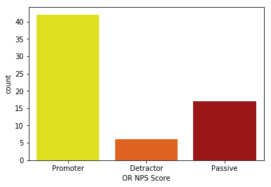

```python
sns.countplot(x='OR NPS Score', palette='hot_r', data=all_data[all_data['OR NPS Score'] != 'None'])
```

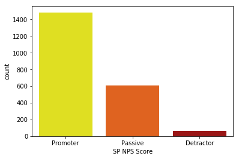

```python
sns.countplot(x='SP NPS Score', palette='hot_r', data=all_data[all_data['SP NPS Score'] != 'None'])
```